# Exercise 2

This exercise requires setting up `mirt()` for estimating MIRT models with the polytomous data provided, and requires applying some useful generic functions suitable for exploratory and confirmatory models. The data is available in the `Exercise_02.Rdata` file.

Load the dataset into R using the `load()` function, and inspect the defined objects. The object named `data` represents a 20-item Likert scale questionnaire, providing a 5 point rating scale for each item describing how unethical a particular situation is. For example, a question might be “Is it wrong for someone to steal a loaf of bread for a starving family of five?”, or “Is it wrong if you don't finish your homework on time for class?”. A coding of 1 = 'strongly disagree', 2 = 'disagree', 3 = 'neutral', 4 = 'agree', and 5 = 'strongly agree'.

The test was designed to ask increasingly more unethical questions, so that in the early stages participants should largely 'disagree', while near the end they should largely 'agree'. Question names also indicate whether the situation was about the behaviour of others (`others`), or behaviour of the individual (`self`).

### 1) Explore the dataset, and fit a unidimenional model using the 'graded' response model (the default`itemtype` for polytomous data).

```r
library(mirt)
load('Exercise_02.Rdata')
psych::describe(data)
```

```
##           vars    n   mean       sd median  trimmed    mad min max range
## self_1       1 2000 1.7515 1.247207      1 1.475625 0.0000   1   5     4
## others_2     2 2000 1.8195 1.277394      1 1.554375 0.0000   1   5     4
## self_3       3 2000 2.1840 1.558319      1 1.980000 0.0000   1   5     4
## self_4       4 2000 2.0490 1.407334      1 1.811250 0.0000   1   5     4
## others_5     5 2000 2.1650 1.471345      1 1.956250 0.0000   1   5     4
## others_6     6 2000 2.3370 1.512804      2 2.171250 1.4826   1   5     4
## self_7       7 2000 2.4880 1.567828      2 2.360000 1.4826   1   5     4
## others_8     8 2000 2.6570 1.598007      3 2.571250 2.9652   1   5     4
## self_9       9 2000 2.8835 1.608484      3 2.854375 2.9652   1   5     4
## self_10     10 2000 2.9490 1.625952      3 2.936250 2.9652   1   5     4
## others_11   11 2000 3.1590 1.621429      3 3.198750 2.9652   1   5     4
## others_12   12 2000 3.2135 1.608170      3 3.266875 2.9652   1   5     4
## others_13   13 2000 3.4360 1.584032      4 3.545000 1.4826   1   5     4
## others_14   14 2000 3.5400 1.567683      4 3.675000 1.4826   1   5     4
## self_15     15 2000 3.6950 1.533020      5 3.868750 0.0000   1   5     4
## self_16     16 2000 3.8375 1.454012      5 4.046875 0.0000   1   5     4
## others_17   17 2000 3.9550 1.449146      5 4.193750 0.0000   1   5     4
## self_18     18 2000 4.0710 1.366343      5 4.338750 0.0000   1   5     4
## self_19     19 2000 4.2085 1.299566      5 4.492500 0.0000   1   5     4
## self_20     20 2000 4.3170 1.191730      5 4.598125 0.0000   1   5     4
##                  skew    kurtosis         se
## self_1     1.49011177  0.94443746 0.02788840
## others_2   1.35461774  0.54403434 0.02856340
## self_3     0.87733866 -0.84848775 0.03484507
## self_4     1.02279240 -0.36084488 0.03146895
## others_5   0.87542156 -0.70784393 0.03290028
## others_6   0.65049883 -1.06598785 0.03382732
## self_7     0.51220106 -1.27270568 0.03505770
## others_8   0.32315964 -1.44966511 0.03573253
## self_9     0.11603085 -1.53209321 0.03596680
## self_10    0.05779132 -1.55829750 0.03635740
## others_11 -0.15774675 -1.54257640 0.03625627
## others_12 -0.19616699 -1.51771873 0.03595978
## others_13 -0.43079185 -1.35360174 0.03542004
## others_14 -0.52087868 -1.27945142 0.03505445
## self_15   -0.70175874 -1.04031887 0.03427937
## self_16   -0.86990086 -0.68440529 0.03251270
## others_17 -1.05530407 -0.38296147 0.03240390
## self_18   -1.20306932  0.04654302 0.03055235
## self_19   -1.44406037  0.72003529 0.02905918
## self_20   -1.65186178  1.55378783 0.02664790
```

```r
mod <- mirt(data, 1)
```

```
##
Iteration: 1, Log-Lik: -50135.808, Max-Change: 0.53189
Iteration: 2, Log-Lik: -50052.720, Max-Change: 0.35452
Iteration: 3, Log-Lik: -50035.102, Max-Change: 0.09336
Iteration: 4, Log-Lik: -50032.808, Max-Change: 0.04725
Iteration: 5, Log-Lik: -50032.264, Max-Change: 0.01031
Iteration: 6, Log-Lik: -50032.160, Max-Change: 0.00581
Iteration: 7, Log-Lik: -50032.126, Max-Change: 0.00348
Iteration: 8, Log-Lik: -50032.106, Max-Change: 0.00260
Iteration: 9, Log-Lik: -50032.097, Max-Change: 0.00150
Iteration: 10, Log-Lik: -50032.089, Max-Change: 0.00227
Iteration: 11, Log-Lik: -50032.087, Max-Change: 0.00010
Iteration: 12, Log-Lik: -50032.087, Max-Change: 0.00049
Iteration: 13, Log-Lik: -50032.086, Max-Change: 0.00010
Iteration: 14, Log-Lik: -50032.086, Max-Change: 0.00042
Iteration: 15, Log-Lik: -50032.086, Max-Change: 0.00007
```

```r
mod
```

```
##
## Call:
## mirt(data = data, model = 1)
##
## Full-information item factor analysis with 1 factor(s).
## Converged within 1e-04 tolerance after 15 EM iterations.
## mirt version: 1.8
## M-step optimizer: BFGS
## EM acceleration: Ramsay
## Number of rectangular quadrature: 41
##
## Log-likelihood = -50032.09
## AIC = 100264.2; AICc = 100274.8
## BIC = 100824.3; SABIC = 100506.6
```

```r
coef(mod, simplify=TRUE)
```

```
## $items
##              a1     d1     d2     d3     d4
## self_1    0.969 -0.873 -1.347 -2.366 -2.939
## others_2  0.962 -0.724 -1.226 -2.279 -2.870
## self_3    1.906 -0.439 -0.969 -1.962 -2.400
## self_4    0.948 -0.313 -0.824 -1.844 -2.341
## others_5  0.889 -0.171 -0.654 -1.609 -2.076
## others_6  0.889  0.089 -0.375 -1.376 -1.925
## self_7    0.868  0.301 -0.217 -1.145 -1.601
## others_8  0.879  0.499  0.034 -0.903 -1.425
## self_9    0.944  0.859  0.326 -0.665 -1.153
## self_10   0.908  0.903  0.427 -0.591 -0.996
## others_11 0.848  1.126  0.667 -0.254 -0.751
## others_12 0.824  1.238  0.701 -0.206 -0.680
## others_13 0.940  1.518  1.081  0.086 -0.399
## others_14 0.875  1.683  1.124  0.233 -0.221
## self_15   0.913  1.869  1.375  0.453  0.002
## self_16   0.884  2.141  1.659  0.635  0.144
## others_17 0.869  2.148  1.718  0.887  0.385
## self_18   0.930  2.507  2.013  1.044  0.556
## self_19   0.927  2.709  2.207  1.309  0.836
## self_20   0.913  3.036  2.527  1.496  0.948
##
## $groupPars
## $groupPars$means
## MEAN_1
##      0
##
## $groupPars$cov
##    F1
## F1  1
```

### 2) Test the dimensionality of the data by extracting 2 and 3 exploratory factors. Use `anova()` to perform a likelihood ratio tests and to compare information statistics, such as AIC and BIC. Note that for the 3-factor solution it may be beneficial to set `TOL = .001` to drop the EM convergence criteria.

```r
mod2 <- mirt(data, 2)
```

```
##
Iteration: 1, Log-Lik: -51624.565, Max-Change: 0.99889
Iteration: 2, Log-Lik: -50098.167, Max-Change: 0.51871
Iteration: 3, Log-Lik: -49883.688, Max-Change: 0.12674
Iteration: 4, Log-Lik: -49866.185, Max-Change: 0.05192
Iteration: 5, Log-Lik: -49860.949, Max-Change: 0.03784
Iteration: 6, Log-Lik: -49858.701, Max-Change: 0.02261
Iteration: 7, Log-Lik: -49856.771, Max-Change: 0.01548
Iteration: 8, Log-Lik: -49856.062, Max-Change: 0.01023
Iteration: 9, Log-Lik: -49855.734, Max-Change: 0.00995
Iteration: 10, Log-Lik: -49854.675, Max-Change: 0.00863
Iteration: 11, Log-Lik: -49854.425, Max-Change: 0.00895
Iteration: 12, Log-Lik: -49854.179, Max-Change: 0.00909
Iteration: 13, Log-Lik: -49852.809, Max-Change: 0.00748
Iteration: 14, Log-Lik: -49852.555, Max-Change: 0.00807
Iteration: 15, Log-Lik: -49852.356, Max-Change: 0.00773
Iteration: 16, Log-Lik: -49851.230, Max-Change: 0.00761
Iteration: 17, Log-Lik: -49851.059, Max-Change: 0.00733
Iteration: 18, Log-Lik: -49850.895, Max-Change: 0.00705
Iteration: 19, Log-Lik: -49850.271, Max-Change: 0.00490
Iteration: 20, Log-Lik: -49850.112, Max-Change: 0.00545
Iteration: 21, Log-Lik: -49849.989, Max-Change: 0.00586
Iteration: 22, Log-Lik: -49849.197, Max-Change: 0.00688
Iteration: 23, Log-Lik: -49849.075, Max-Change: 0.00637
Iteration: 24, Log-Lik: -49848.962, Max-Change: 0.00564
Iteration: 25, Log-Lik: -49848.388, Max-Change: 0.00510
Iteration: 26, Log-Lik: -49848.248, Max-Change: 0.00543
Iteration: 27, Log-Lik: -49848.160, Max-Change: 0.00476
Iteration: 28, Log-Lik: -49847.772, Max-Change: 0.00499
Iteration: 29, Log-Lik: -49847.671, Max-Change: 0.00517
Iteration: 30, Log-Lik: -49847.596, Max-Change: 0.00426
Iteration: 31, Log-Lik: -49847.276, Max-Change: 0.00400
Iteration: 32, Log-Lik: -49847.189, Max-Change: 0.00332
Iteration: 33, Log-Lik: -49847.135, Max-Change: 0.00469
Iteration: 34, Log-Lik: -49846.874, Max-Change: 0.00351
Iteration: 35, Log-Lik: -49846.816, Max-Change: 0.00348
Iteration: 36, Log-Lik: -49846.765, Max-Change: 0.00361
Iteration: 37, Log-Lik: -49846.493, Max-Change: 0.00329
Iteration: 38, Log-Lik: -49846.432, Max-Change: 0.00285
Iteration: 39, Log-Lik: -49846.396, Max-Change: 0.00385
```

[output cut: 121 more lines]

```
Iteration: 161, Log-Lik: -49845.011, Max-Change: 0.00038
Iteration: 162, Log-Lik: -49845.011, Max-Change: 0.00019
Iteration: 163, Log-Lik: -49845.011, Max-Change: 0.00015
Iteration: 164, Log-Lik: -49845.010, Max-Change: 0.00025
Iteration: 165, Log-Lik: -49845.010, Max-Change: 0.00011
Iteration: 166, Log-Lik: -49845.010, Max-Change: 0.00045
Iteration: 167, Log-Lik: -49845.010, Max-Change: 0.00023
Iteration: 168, Log-Lik: -49845.010, Max-Change: 0.00033
Iteration: 169, Log-Lik: -49845.010, Max-Change: 0.00027
Iteration: 170, Log-Lik: -49845.009, Max-Change: 0.00041
Iteration: 171, Log-Lik: -49845.009, Max-Change: 0.00021
Iteration: 172, Log-Lik: -49845.009, Max-Change: 0.00016
Iteration: 173, Log-Lik: -49845.009, Max-Change: 0.00024
Iteration: 174, Log-Lik: -49845.009, Max-Change: 0.00012
Iteration: 175, Log-Lik: -49845.009, Max-Change: 0.00009
```

```r
mod2
```

```
##
## Call:
## mirt(data = data, model = 2)
##
## Full-information item factor analysis with 2 factor(s).
## Converged within 1e-04 tolerance after 175 EM iterations.
## mirt version: 1.8
## M-step optimizer: BFGS
## EM acceleration: Ramsay
## Number of rectangular quadrature: 21
##
## Log-likelihood = -49845.01
## AIC = 99928.02; AICc = 99943.21
## BIC = 100594.5; SABIC = 100216.5
```

```r
# much better fit with 2 dimensions, with all criteria
anova(mod, mod2)
```

```
##
## Model 1: mirt(data = data, model = 1)
## Model 2: mirt(data = data, model = 2)
```

```
##         AIC      AICc    SABIC      BIC    logLik      X2  df   p
## 1 100264.17 100274.81 100506.6 100824.3 -50032.09     NaN NaN NaN
## 2  99928.02  99943.21 100216.5 100594.5 -49845.01 374.154  19   0
```

```r
mod3 <- mirt(data, 3, TOL = .001, verbose = FALSE)
# BIC information stats suggest 2 dims
anova(mod2, mod3)
```

```
##
## Model 1: mirt(data = data, model = 2)
## Model 2: mirt(data = data, model = 3, TOL = 0.001, verbose = FALSE)
```

```
##        AIC     AICc    SABIC      BIC    logLik     X2  df      p
## 1 99928.02 99943.21 100216.5 100594.5 -49845.01    NaN NaN    NaN
## 2 99921.98 99942.29 100254.1 100689.3 -49823.99 42.035  18 0.0011
```

```r
# third factor not well defined. Two probably best
summary(mod3, suppress=.1)
```

```
##
## Rotation:  oblimin
##
## Rotated factor loadings:
##
##              F1    F2     F3    h2
## self_1    0.549    NA     NA 0.308
## others_2     NA 0.526     NA 0.295
## self_3    0.335 0.479     NA 0.558
## self_4    0.576    NA  0.209 0.353
## others_5     NA 0.519     NA 0.274
## others_6     NA 0.528     NA 0.270
## self_7    0.477    NA     NA 0.250
## others_8     NA 0.530     NA 0.270
## self_9    0.443    NA -0.209 0.314
## self_10   0.514    NA     NA 0.276
## others_11    NA 0.528     NA 0.264
## others_12    NA 0.564     NA 0.271
## others_13    NA 0.455     NA 0.262
## others_14    NA 0.481  0.200 0.300
## self_15   0.529    NA     NA 0.282
## self_16   0.439    NA -0.290 0.336
## others_17    NA 0.506  0.109 0.274
## self_18   0.488    NA     NA 0.279
## self_19   0.512    NA     NA 0.276
## self_20   0.515    NA     NA 0.277
##
## Rotated SS loadings:  2.689 2.639 0.263
##
## Factor correlations:
##
##        F1     F2     F3
## F1  1.000  0.667 -0.117
## F2  0.667  1.000 -0.063
## F3 -0.117 -0.063  1.000
```

### 3) Using the 2-factor model, attempt to rotate the solution to an interpretable orientation using the `summary()` function with a `rotate =` argument. Try using the `varimax` and `oblimin` criteria, and suppress coefficients with the `suppress =` argument (takes a number and replaces values below with NA's). Do you notice any discernable pattern in the loadings?

```r
summary(mod2, rotate = 'varimax')
```

```
##
## Rotation:  varimax
##
## Rotated factor loadings:
##
##              F1    F2    h2
## self_1    0.501 0.207 0.294
## others_2  0.214 0.486 0.282
## self_3    0.490 0.561 0.555
## self_4    0.477 0.218 0.275
## others_5  0.193 0.467 0.255
## others_6  0.179 0.483 0.265
## self_7    0.447 0.200 0.240
## others_8  0.176 0.485 0.266
## self_9    0.473 0.220 0.272
## self_10   0.487 0.188 0.273
## others_11 0.172 0.466 0.247
## others_12 0.130 0.499 0.266
## others_13 0.239 0.448 0.258
## others_14 0.191 0.463 0.250
## self_15   0.498 0.178 0.279
## self_16   0.469 0.189 0.256
## others_17 0.176 0.476 0.258
## self_18   0.482 0.200 0.272
## self_19   0.482 0.195 0.270
## self_20   0.492 0.180 0.275
##
## Rotated SS loadings:  2.869 2.738
##
## Factor correlations:
##
##    F1 F2
## F1  1  0
## F2  0  1
```

```r
summary(mod2, rotate = 'oblimin')
```

```
##
## Rotation:  oblimin
##
## Rotated factor loadings:
##
##               F1     F2    h2
## self_1     0.538  0.006 0.294
## others_2   0.027  0.512 0.282
## self_3     0.344  0.465 0.555
## self_4     0.501  0.033 0.275
## others_5   0.010  0.499 0.255
## others_6  -0.016  0.526 0.265
## self_7     0.472  0.025 0.240
## others_8  -0.021  0.530 0.266
## self_9     0.495  0.037 0.272
## self_10    0.530 -0.012 0.273
## others_11 -0.016  0.508 0.247
## others_12 -0.087  0.572 0.266
## others_13  0.080  0.449 0.258
## others_14  0.009  0.494 0.250
## self_15    0.549 -0.030 0.279
## self_16    0.506 -0.001 0.256
## others_17 -0.017  0.519 0.258
## self_18    0.518  0.006 0.272
## self_19    0.519  0.001 0.270
## self_20    0.540 -0.024 0.275
##
## Rotated SS loadings:  2.81 2.589
##
## Factor correlations:
##
##      F1   F2
## F1 1.00 0.69
## F2 0.69 1.00
```

```r
summary(mod2, rotate = 'oblimin', suppress = .2)
```

```
##
## Rotation:  oblimin
##
## Rotated factor loadings:
##
##              F1    F2    h2
## self_1    0.538    NA 0.294
## others_2     NA 0.512 0.282
## self_3    0.344 0.465 0.555
## self_4    0.501    NA 0.275
## others_5     NA 0.499 0.255
## others_6     NA 0.526 0.265
## self_7    0.472    NA 0.240
## others_8     NA 0.530 0.266
## self_9    0.495    NA 0.272
## self_10   0.530    NA 0.273
## others_11    NA 0.508 0.247
## others_12    NA 0.572 0.266
## others_13    NA 0.449 0.258
## others_14    NA 0.494 0.250
## self_15   0.549    NA 0.279
## self_16   0.506    NA 0.256
## others_17    NA 0.519 0.258
## self_18   0.518    NA 0.272
## self_19   0.519    NA 0.270
## self_20   0.540    NA 0.275
##
## Rotated SS loadings:  2.81 2.589
##
## Factor correlations:
##
##      F1   F2
## F1 1.00 0.69
## F2 0.69 1.00
```

### 4) Given the pattern you observed in question 3, create a more restricted confirmatory model using the `mirt.model()` syntax. Use `anova()` to determine if the confirmatory model fits significantly worse than the exploratory model, and inspect and interpret the estimated coefficients.

```r
model <- mirt.model('self = 1,3,4,7,9,10,15,16,18,19,20
                     others = 2,3,5,6,8,11-14,17
                     COV = self*others')
cmod <- mirt(data, model)
```

```
##
Iteration: 1, Log-Lik: -50037.152, Max-Change: 0.16880
Iteration: 2, Log-Lik: -49922.497, Max-Change: 0.08944
Iteration: 3, Log-Lik: -49880.784, Max-Change: 0.05405
Iteration: 4, Log-Lik: -49865.774, Max-Change: 0.03471
Iteration: 5, Log-Lik: -49858.766, Max-Change: 0.02379
Iteration: 6, Log-Lik: -49855.168, Max-Change: 0.01672
Iteration: 7, Log-Lik: -49853.183, Max-Change: 0.01221
Iteration: 8, Log-Lik: -49852.029, Max-Change: 0.00913
Iteration: 9, Log-Lik: -49851.342, Max-Change: 0.00695
Iteration: 10, Log-Lik: -49850.899, Max-Change: 0.00571
Iteration: 11, Log-Lik: -49850.620, Max-Change: 0.00430
Iteration: 12, Log-Lik: -49850.461, Max-Change: 0.00332
Iteration: 13, Log-Lik: -49850.364, Max-Change: 0.00258
Iteration: 14, Log-Lik: -49850.303, Max-Change: 0.00204
Iteration: 15, Log-Lik: -49850.265, Max-Change: 0.00160
Iteration: 16, Log-Lik: -49850.239, Max-Change: 0.00130
Iteration: 17, Log-Lik: -49850.223, Max-Change: 0.00103
Iteration: 18, Log-Lik: -49850.213, Max-Change: 0.00082
Iteration: 19, Log-Lik: -49850.207, Max-Change: 0.00065
Iteration: 20, Log-Lik: -49850.202, Max-Change: 0.00053
Iteration: 21, Log-Lik: -49850.199, Max-Change: 0.00042
Iteration: 22, Log-Lik: -49850.197, Max-Change: 0.00035
Iteration: 23, Log-Lik: -49850.196, Max-Change: 0.00032
Iteration: 24, Log-Lik: -49850.195, Max-Change: 0.00023
Iteration: 25, Log-Lik: -49850.195, Max-Change: 0.00018
Iteration: 26, Log-Lik: -49850.194, Max-Change: 0.00030
Iteration: 27, Log-Lik: -49850.194, Max-Change: 0.00012
Iteration: 28, Log-Lik: -49850.194, Max-Change: 0.00029
Iteration: 29, Log-Lik: -49850.194, Max-Change: 0.00008
```

```r
anova(mod2, cmod)
```

```
##
## Model 1: mirt(data = data, model = model)
## Model 2: mirt(data = data, model = 2)
```

```
##        AIC     AICc    SABIC      BIC    logLik    X2  df      p
## 1 99904.39 99915.46 100151.6 100475.7 -49850.19   NaN NaN    NaN
## 2 99928.02 99943.21 100216.5 100594.5 -49845.01 10.37  17 0.8874
```

```r
coef(cmod)
```

```
## $self_1
##        a1 a2     d1     d2     d3     d4
## par 1.099  0 -0.905 -1.396 -2.449 -3.035
##
## $others_2
##     a1    a2     d1     d2    d3     d4
## par  0 1.081 -0.749 -1.267 -2.35 -2.954
##
## $self_3
##        a1    a2     d1     d2     d3     d4
## par 0.885 1.176 -0.438 -0.968 -1.959 -2.395
##
## $self_4
##        a1 a2     d1    d2     d3    d4
## par 1.057  0 -0.323 -0.85 -1.902 -2.41
##
## $others_5
##     a1    a2     d1     d2     d3     d4
## par  0 1.003 -0.179 -0.679 -1.662 -2.141
##
## $others_6
##     a1    a2    d1     d2     d3     d4
## par  0 1.015 0.091 -0.391 -1.429 -1.994
##
## $self_7
##        a1 a2    d1     d2    d3     d4
## par 0.963  0 0.308 -0.227 -1.18 -1.646
##
## $others_8
##     a1    a2    d1    d2     d3     d4
## par  0 1.017 0.518 0.032 -0.941 -1.482
##
## $self_9
##        a1 a2    d1    d2     d3     d4
## par 1.054  0 0.887 0.337 -0.684 -1.188
##
## $self_10
##        a1 a2    d1   d2     d3     d4
## par 1.033  0 0.934 0.44 -0.616 -1.035
##
```

[output cut: 28 more lines]

```
## $self_18
##        a1 a2    d1    d2    d3    d4
## par 1.047  0 2.585 2.079 1.083 0.579
##
## $self_19
##        a1 a2    d1    d2    d3    d4
## par 1.031  0 2.785 2.274 1.353 0.865
##
## $self_20
##        a1 a2   d1   d2    d3    d4
## par 1.036  0 3.13 2.61 1.552 0.985
##
## $GroupPars
##     MEAN_1 MEAN_2 COV_11 COV_21 COV_22
## par      0      0      1  0.691      1
```

```r
#coefs as a data.frame
coef(cmod, as.data.frame=TRUE)
```

```
##                     par
## self_1.a1         1.099
## self_1.a2         0.000
## self_1.d1        -0.905
## self_1.d2        -1.396
## self_1.d3        -2.449
## self_1.d4        -3.035
## others_2.a1       0.000
## others_2.a2       1.081
## others_2.d1      -0.749
## others_2.d2      -1.267
## others_2.d3      -2.350
## others_2.d4      -2.954
## self_3.a1         0.885
## self_3.a2         1.176
## self_3.d1        -0.438
## self_3.d2        -0.968
## self_3.d3        -1.959
## self_3.d4        -2.395
## self_4.a1         1.057
## self_4.a2         0.000
## self_4.d1        -0.323
## self_4.d2        -0.850
## self_4.d3        -1.902
## self_4.d4        -2.410
## others_5.a1       0.000
## others_5.a2       1.003
## others_5.d1      -0.179
## others_5.d2      -0.679
## others_5.d3      -1.662
## others_5.d4      -2.141
## others_6.a1       0.000
## others_6.a2       1.015
## others_6.d1       0.091
## others_6.d2      -0.391
## others_6.d3      -1.429
## others_6.d4      -1.994
## self_7.a1         0.963
## self_7.a2         0.000
## self_7.d1         0.308
```

[output cut: 71 more lines]

```
## self_19.d1        2.785
## self_19.d2        2.274
## self_19.d3        1.353
## self_19.d4        0.865
## self_20.a1        1.036
## self_20.a2        0.000
## self_20.d1        3.130
## self_20.d2        2.610
## self_20.d3        1.552
## self_20.d4        0.985
## GroupPars.MEAN_1  0.000
## GroupPars.MEAN_2  0.000
## GroupPars.COV_11  1.000
## GroupPars.COV_21  0.691
## GroupPars.COV_22  1.000
```

### 5) Compute EAP factor scores for the confirmatory model, returning both the tabulated form (a potentially smaller data.frame consisting of estimates for each unique response pattern) and the complete data form (applied to the original dataset, returning estimates for each person).

```r
tab <- fscores(cmod, method = 'EAP')
```

```
##
## Method:  EAP
##
## Empirical Reliability:
##     F1     F2
## 0.7705 0.7658
```

```r
head(tab)
```

```
##      self_1 others_2 self_3 self_4 others_5 others_6 self_7 others_8
## [1,]      1        1      1      1        1        1      1        1
## [2,]      1        1      1      1        1        1      1        1
## [3,]      1        1      1      1        1        1      1        1
## [4,]      1        1      1      1        1        1      1        1
## [5,]      1        1      1      1        1        1      1        1
## [6,]      1        1      1      1        1        1      1        1
##      self_9 self_10 others_11 others_12 others_13 others_14 self_15
## [1,]      1       1         1         1         1         1       1
## [2,]      1       1         1         1         1         1       1
## [3,]      1       1         1         1         1         1       2
## [4,]      1       1         1         1         1         1       5
## [5,]      1       1         1         1         1         1       5
## [6,]      1       1         1         1         1         1       5
##      self_16 others_17 self_18 self_19 self_20      F1      F2  SE_F1
## [1,]       1         5       2       5       1 -2.2419 -2.1088 0.5491
## [2,]       4         3       3       1       3 -2.0503 -2.1776 0.5167
## [3,]       1         5       3       4       3 -1.8509 -1.9539 0.4855
## [4,]       2         4       3       3       1 -1.8073 -2.0145 0.5066
## [5,]       4         5       5       5       3 -1.0538 -1.6573 0.4999
## [6,]       5         1       2       5       1 -1.5605 -2.2450 0.5439
##       SE_F2
## [1,] 0.5949
## [2,] 0.5684
## [3,] 0.5759
## [4,] 0.5653
## [5,] 0.5588
## [6,] 0.5897
```

```r
full <- fscores(cmod, method = 'EAP', full.scores = TRUE)
head(full)
```

```
##              F1         F2
## [1,]  0.6748615  0.2276764
## [2,]  1.2040569  0.5323854
## [3,] -1.2945576 -1.0575905
## [4,] -1.5461471 -1.5450923
## [5,]  0.5782413  0.5535808
## [6,] -1.2645892 -1.2037039
```

### 6) You would like to know if the item categories can be simplified by forcing the spacing between each category in each item to be the same, and using only 1 intercept to represent the total rating 'easiness' (these models are generally called rating scale models, and are useful for creating parsimonious models with more elegant interpretations). Fit a graded rating scale model (`itemtype = 'grsm'`) to the data, test whether the model fit significantly worse than the confirmatory model above, and inspect/interpret the coefficients.

```r
rating <- mirt(data, model, itemtype = 'grsm')
```

```
##
Iteration: 1, Log-Lik: -55289.927, Max-Change: 2.47383
Iteration: 2, Log-Lik: -52135.663, Max-Change: 0.57930
Iteration: 3, Log-Lik: -50873.428, Max-Change: 0.46168
Iteration: 4, Log-Lik: -50621.806, Max-Change: 0.57002
Iteration: 5, Log-Lik: -50421.906, Max-Change: 0.34718
Iteration: 6, Log-Lik: -50222.853, Max-Change: 0.29119
Iteration: 7, Log-Lik: -50127.867, Max-Change: 0.22587
Iteration: 8, Log-Lik: -50069.344, Max-Change: 0.19213
Iteration: 9, Log-Lik: -50004.836, Max-Change: 0.19866
Iteration: 10, Log-Lik: -49956.999, Max-Change: 0.08157
Iteration: 11, Log-Lik: -49937.965, Max-Change: 0.06318
Iteration: 12, Log-Lik: -49920.584, Max-Change: 0.06310
Iteration: 13, Log-Lik: -49909.974, Max-Change: 0.08655
Iteration: 14, Log-Lik: -49900.294, Max-Change: 0.07811
Iteration: 15, Log-Lik: -49893.371, Max-Change: 0.06818
Iteration: 16, Log-Lik: -49888.969, Max-Change: 0.04602
Iteration: 17, Log-Lik: -49886.591, Max-Change: 0.02650
Iteration: 18, Log-Lik: -49884.964, Max-Change: 0.02603
Iteration: 19, Log-Lik: -49884.013, Max-Change: 0.00906
Iteration: 20, Log-Lik: -49882.954, Max-Change: 0.00926
Iteration: 21, Log-Lik: -49882.172, Max-Change: 0.00722
Iteration: 22, Log-Lik: -49881.034, Max-Change: 0.00721
Iteration: 23, Log-Lik: -49880.867, Max-Change: 0.00252
Iteration: 24, Log-Lik: -49880.788, Max-Change: 0.00697
Iteration: 25, Log-Lik: -49880.681, Max-Change: 0.00551
Iteration: 26, Log-Lik: -49880.609, Max-Change: 0.00110
Iteration: 27, Log-Lik: -49880.587, Max-Change: 0.00097
Iteration: 28, Log-Lik: -49880.559, Max-Change: 0.00138
Iteration: 29, Log-Lik: -49880.537, Max-Change: 0.00101
Iteration: 30, Log-Lik: -49880.528, Max-Change: 0.00035
Iteration: 31, Log-Lik: -49880.527, Max-Change: 0.00021
Iteration: 32, Log-Lik: -49880.526, Max-Change: 0.00018
Iteration: 33, Log-Lik: -49880.525, Max-Change: 0.00023
Iteration: 34, Log-Lik: -49880.525, Max-Change: 0.00015
Iteration: 35, Log-Lik: -49880.524, Max-Change: 0.00017
Iteration: 36, Log-Lik: -49880.523, Max-Change: 0.00018
Iteration: 37, Log-Lik: -49880.523, Max-Change: 0.00015
Iteration: 38, Log-Lik: -49880.522, Max-Change: 0.00015
Iteration: 39, Log-Lik: -49880.522, Max-Change: 0.00018
Iteration: 40, Log-Lik: -49880.521, Max-Change: 0.00013
Iteration: 41, Log-Lik: -49880.521, Max-Change: 0.00015
Iteration: 42, Log-Lik: -49880.521, Max-Change: 0.00015
Iteration: 43, Log-Lik: -49880.520, Max-Change: 0.00012
Iteration: 44, Log-Lik: -49880.520, Max-Change: 0.00013
Iteration: 45, Log-Lik: -49880.519, Max-Change: 0.00015
Iteration: 46, Log-Lik: -49880.519, Max-Change: 0.00011
Iteration: 47, Log-Lik: -49880.519, Max-Change: 0.00012
Iteration: 48, Log-Lik: -49880.519, Max-Change: 0.00013
Iteration: 49, Log-Lik: -49880.518, Max-Change: 0.00011
Iteration: 50, Log-Lik: -49880.518, Max-Change: 0.00011
Iteration: 51, Log-Lik: -49880.518, Max-Change: 0.00013
Iteration: 52, Log-Lik: -49880.517, Max-Change: 0.00009
```

```r
# save 57 degrees of freedom! Maybe more if slopes could also be constrained to be equal...
anova(rating, cmod)
```

```
##
## Model 1: mirt(data = data, model = model, itemtype = "grsm")
## Model 2: mirt(data = data, model = model)
```

```
##        AIC     AICc     SABIC      BIC    logLik     X2  df      p
## 1 99851.03 99853.15  99960.11 100103.1 -49880.52    NaN NaN    NaN
## 2 99904.39 99915.46 100151.62 100475.7 -49850.19 60.648  57 0.3458
```

```r
# c parameter indicates the relative easiness of the item
# (i.e., tendencies to respond in higher categories). Shows that the items systematically
# move from subjects selecting strongly disagree to strongly agree
coef(rating)
```

```
## $self_1
##        a1 a2     d1     d2     d3     d4 c
## par 1.079  0 -0.912 -1.421 -2.413 -2.915 0
##
## $others_2
##     a1    a2     d1     d2     d3     d4    c
## par  0 1.036 -0.912 -1.421 -2.413 -2.915 0.15
##
## $self_3
##        a1    a2     d1     d2     d3     d4     c
## par 0.897 1.184 -0.912 -1.421 -2.413 -2.915 0.463
##
## $self_4
##        a1 a2     d1     d2     d3     d4     c
## par 1.029  0 -0.912 -1.421 -2.413 -2.915 0.571
##
## $others_5
##     a1    a2     d1     d2     d3     d4     c
## par  0 1.012 -0.912 -1.421 -2.413 -2.915 0.739
##
## $others_6
##     a1    a2     d1     d2     d3     d4     c
## par  0 0.993 -0.912 -1.421 -2.413 -2.915 0.996
##
## $self_7
##        a1 a2     d1     d2     d3     d4     c
## par 0.978  0 -0.912 -1.421 -2.413 -2.915 1.222
##
## $others_8
##     a1    a2     d1     d2     d3     d4     c
## par  0 1.024 -0.912 -1.421 -2.413 -2.915 1.441
##
## $self_9
##        a1 a2     d1     d2     d3     d4     c
## par 1.026  0 -0.912 -1.421 -2.413 -2.915 1.756
##
## $self_10
##        a1 a2     d1     d2     d3     d4     c
## par 1.041  0 -0.912 -1.421 -2.413 -2.915 1.847
##
```

[output cut: 28 more lines]

```
## $self_18
##        a1 a2     d1     d2     d3     d4     c
## par 1.047  0 -0.912 -1.421 -2.413 -2.915 3.493
##
## $self_19
##        a1 a2     d1     d2     d3     d4     c
## par 1.058  0 -0.912 -1.421 -2.413 -2.915 3.769
##
## $self_20
##        a1 a2     d1     d2     d3     d4     c
## par 0.994  0 -0.912 -1.421 -2.413 -2.915 3.912
##
## $GroupPars
##     MEAN_1 MEAN_2 COV_11 COV_21 COV_22
## par      0      0      1  0.691      1
```

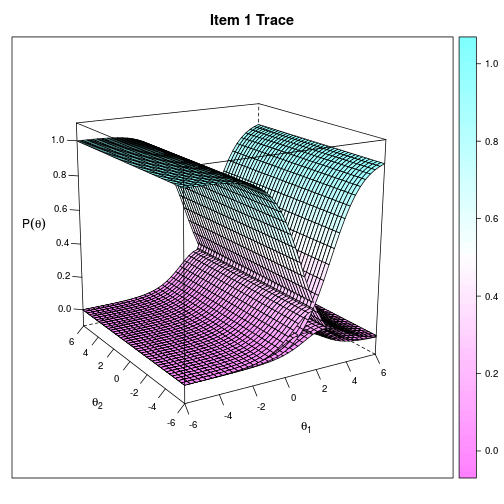

```r
itemplot(rating, 1)
```

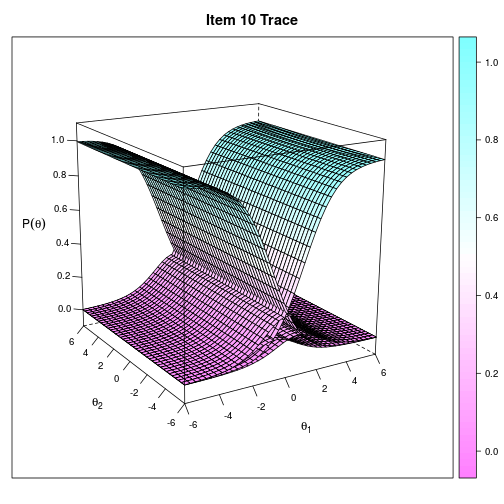

```r
itemplot(rating, 10)
```

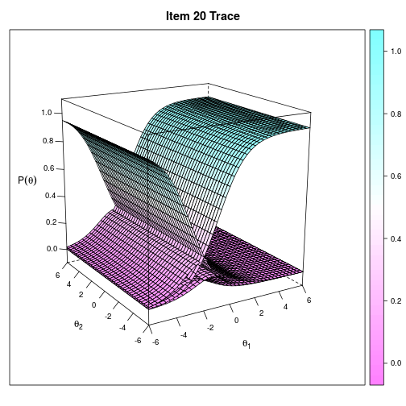

```r
itemplot(rating, 20)
```

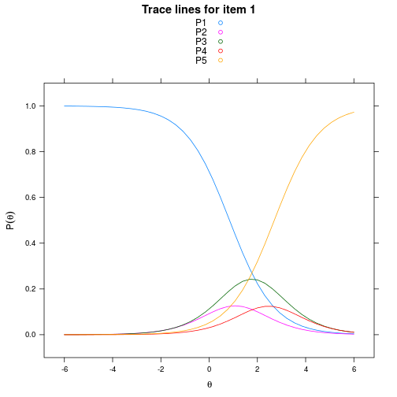

```r
# dropping slopes exactly equal to 0 (easier to visualize)
itemplot(rating, 1, drop.zeros = TRUE)
```

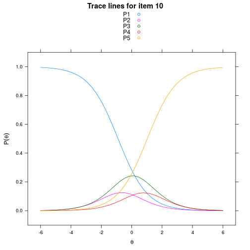

```r
itemplot(rating, 10, drop.zeros = TRUE)
```

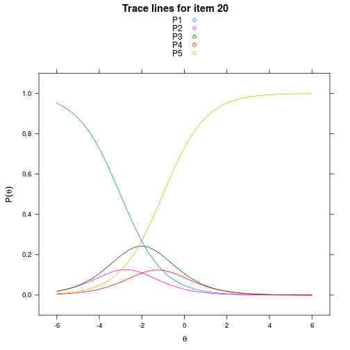

```r
itemplot(rating, 20, drop.zeros = TRUE)
```